# Лабораторная работа №2

```python
import numpy as np
import pandas as pd
import matplotlib.pyplot as plt
from scipy.special import expit
from sklearn.model_selection import train_test_split, GridSearchCV
from sklearn.base import BaseEstimator
from sklearn.utils.multiclass import check_classification_targets
from sklearn.utils.validation import check_X_y, check_array, check_is_fitted

plt.rcParams["figure.figsize"] = (20,10)
```

Загрузим данные и разделим на обучающий и тестовый сет.

```python
df = pd.read_csv('./2_features/1.csv')
X = df.iloc[:, 0:2].to_numpy()
y = df.iloc[:, 2].to_numpy()

X_train, X_test, y_train, y_test = train_test_split(X, y, test_size=0.2, random_state=88)

N_train = X_train.shape[0]
N_test = X_test.shape[0]
X_train = np.hstack((np.ones((N_train, 1)), X_train))
X_test = np.hstack((np.ones((N_test, 1)), X_test))
```

```python
def batch_split(X, y, batch_size):
    data_size = y.size
    if batch_size == -1:
        batch_size = y.size

    packs_cnt = int(data_size / batch_size)
    X_batchs = np.array_split(X, packs_cnt)
    y_batchs = np.array_split(y, packs_cnt)
    return X_batchs, y_batchs


def logloss(y, y_pred):
    eps=1e-15
    y_pred = np.clip(y_pred, eps, 1 - eps)
    return -np.dot(y.T, np.log(y_pred)) - np.dot(1 - y.T, np.log(1 - y_pred))


def accuracy(X, y, w):
    y_pred = expit(np.dot(X, w)) >= 0.5
    correct_num = np.count_nonzero(y_pred == y)
    return correct_num / len(y)


def loss(X, y, w):
    y_proba = expit(np.dot(X, w))
    return logloss(y, y_proba)
```

Реализуем метод momentum.

```python
class MomentumMethod(BaseEstimator):
    def __init__(self, l_rate=1e-3, gamma=0.9, epocs=100, batch_size=-1, random_base=88):
        self.l_rate = l_rate
        self.gamma = gamma
        self.epocs = epocs
        self.batch_size = batch_size
        self.random_base = random_base


    def fit(self, X, y):
        X, y = check_X_y(X, y)
        check_classification_targets(y)

        X_batchs, y_batchs = batch_split(X, y, self.batch_size)
        batch_cnt = len(y_batchs)
        eps = 1e-4
        cnt = 0
        self.used_vecs_ = 0
        self.weights_list_ = np.zeros((batch_cnt * self.epocs, X.shape[1]), dtype=np.float64)
        self.used_vecs_ = np.zeros((batch_cnt * self.epocs, 1), dtype=np.uint32)

        w_i = np.random.RandomState(self.random_base).uniform(-1.0, 1.0, X_batchs[0].shape[1])
        v_prev = np.zeros_like(w_i)
        self.w_ = w_i
        for p_ in range(self.epocs):
            for i in range(batch_cnt):
                y_pred = expit(np.dot(X_batchs[i], self.w_))
                grad = np.dot(X_batchs[i].T, y_pred - y_batchs[i])

                v_prev = self.gamma * v_prev - self.l_rate * grad
                self.w_ += v_prev

                self.weights_list_[cnt] = self.w_
                self.used_vecs_[cnt] = y_pred.size
                cnt += 1

                if np.linalg.norm(grad) <= eps:
                    print(f'Stopped by epsilon on {p_} epoc')
                    self.used_vecs_ = self.used_vecs_[0:cnt]
                    self.weights_list_ = self.weights_list_[0:cnt]
                    return self

        return self

    def predict(self, X):
        check_is_fitted(self, [])
        X = check_array(X)

        y_proba = expit(np.dot(X, self.w_))
        return y_proba >= 0.5

    def score(self, X, y):
        correct_num = np.count_nonzero(self.predict(X) == y)
        return correct_num / len(y)

class GradientDescent(MomentumMethod):
    def __init__(self, l_rate=1e-3, epocs=100, batch_size=-1, random_base=88):
        super().__init__(l_rate=l_rate, gamma=0.0, epocs=epocs, batch_size=batch_size, random_base=random_base)
```

Будем искать лучшую модель при помощи кросс-валидации

```python
def get_best_model(estimator, param_grid):
    grid_model = GridSearchCV(estimator, param_grid=param_grid, n_jobs=-1, cv=3)
    grid_model.fit(X_train, y_train)
    best_model = grid_model.best_estimator_

    print(f'Best params: {grid_model.best_params_}')
    print(f'Logloss: {loss(X_train, y_train, best_model.w_)}')
    print(f'Train accuracy: {best_model.score(X_train, y_train)}')
    print(f'Test accuracy: {best_model.score(X_test, y_test)}')

    w0, w1, w2 = best_model.w_
    print(f'Line equation: y = {-w1 / w2} * x + {-w0 / w2}')

    return best_model
```

## Vanilla Gradient Descent (VGD)

batch_size = -1, т.е. градиент считается сразу для всего тренировочного набора.

Для VGD и остальных методов будем строить модели следующим образом: сначала будем подбирать параметр $\alpha$ для модели, которая использует базовый градиентный спуск. Затем будем использовать подобранный $\alpha$ для модели, которая использует momentum, и будем подбирать $\gamma$.

```python
params = {
    'l_rate': np.geomspace(1e-4, 1e-1, 10)
}

vgd_model = get_best_model(GradientDescent(epocs=100, batch_size=-1), params)
```

```
Best params: {'l_rate': 0.00021544346900318845}
Logloss: 793.6218444134297
Train accuracy: 0.8632763651521467
Test accuracy: 0.8733333333333333
Line equation: y = 2.614947382318598 * x + 2.6548213943998533
```

```python
params = {
    'gamma': np.arange(0.1, 1.0, 0.1)
}

momentum_vgd_model = get_best_model(MomentumMethod(epocs=100, batch_size=-1, l_rate=vgd_model.l_rate), params)
```

```
Best params: {'gamma': 0.1}
Logloss: 791.7546879894768
Train accuracy: 0.8628595248020008
Test accuracy: 0.88
Line equation: y = 2.596593236208563 * x + 2.658160712709411
```

Все модели показали похожий результат на обучающей и тестовой выборках.

## Stochastic gradient descent (SGD)¶

batch_size = 1, т.е. градиент пересчитывается для каждого тестового вектора.

```python
params = {
    'l_rate': np.geomspace(1e-4, 1e-1, 10)
}

sgd_model = get_best_model(GradientDescent(epocs=100, batch_size=1), params)
```

```
Stopped by epsilon on 3 epoc
Best params: {'l_rate': 0.021544346900318822}
Logloss: 788.2128809900898
Train accuracy: 0.8603584827011255
Test accuracy: 0.88
Line equation: y = 2.7311082914467657 * x + 2.8291922549658355
```

```python
params = {
    'gamma': np.arange(0.1, 1.0, 0.1)
}

momentum_sgd_model = get_best_model(MomentumMethod(epocs=100, batch_size=1, l_rate=sgd_model.l_rate), params)
```

```
Stopped by epsilon on 3 epoc
Best params: {'gamma': 0.2}
Logloss: 789.2939341670395
Train accuracy: 0.8599416423509796
Test accuracy: 0.8783333333333333
Line equation: y = 2.8425244397436926 * x + 2.90983935006191
```

В этом случае точности для разных моделей так же довольно схожи.

## Mini-bacth gradient descent (MBGD)

batch_size = N, где N меньше количества тренировочных данных. Возьмем batch_size = 32

```python
params = {
    'l_rate': np.geomspace(1e-4, 1e-1, 10),
}

mbgd_model = get_best_model(GradientDescent(epocs=100, batch_size=32), params)
```

```
Best params: {'l_rate': 0.021544346900318822}
Logloss: 788.7532491439306
Train accuracy: 0.8636932055022927
Test accuracy: 0.8716666666666667
Line equation: y = 2.624910348770193 * x + 2.642488707780735
```

```python
params = {
    'gamma': np.arange(0.1, 1.0, 0.1)
}

momentum_mbgd_model = get_best_model(MomentumMethod(epocs=100, batch_size=32, l_rate=mbgd_model.l_rate), params)
```

```
Best params: {'gamma': 0.1}
Logloss: 788.4991699860957
Train accuracy: 0.8632763651521467
Test accuracy: 0.8733333333333333
Line equation: y = 2.5976562301481745 * x + 2.626673669979872
```

Значения также крайне схожи.

Построим график зависимости ошибки, точности на тестовых и тренировочных данных в зависимости от количества использованных векторов.

```python
def get_errors(weights, X, y):
    errors = np.empty((weights.shape[0]))
    for i in range(errors.size):
        y_pred = expit(np.dot(X, weights[i]))
        errors[i] = logloss(y, y_pred)

    return errors

def plot_stats(estimator, legend_str, plotting_grid):
    def help_plot(ax, title, xlabel, ylabel):
        ax.set_title(title)
        ax.set_xlabel(xlabel)
        ax.set_ylabel(ylabel)
        ax.legend()
        ax.grid()

    uv = np.cumsum(estimator.used_vecs_)
    print('Used vectors: ', uv[-1])
    weights = estimator.weights_list_
    errors = get_errors(weights, X_train, y_train)

    acc_train = [accuracy(X_train, y_train, w) for w in weights]
    acc_test = [accuracy(X_test, y_test, w) for w in weights]

    ax0, ax1, ax2 = plotting_grid
    ax0.plot(uv, errors, label=legend_str)
    help_plot(ax0, 'Error function', 'used vecs', 'LogLoss function')

    ax1.plot(uv, acc_train, label=legend_str)
    help_plot(ax1, 'Train accuracy', 'used vecs', 'Train accuracy')
    acc_train_min, acc_train_max = np.min(acc_train), np.max(acc_train)
    ax1.set_ylim([acc_train_min - 0.01, acc_train_max + 0.01])

    ax2.plot(uv, acc_test, label=legend_str)
    help_plot(ax2, 'Test accuracy', 'used vecs', 'Test accuracy')
    acc_test_min, acc_test_max = np.min(acc_test), np.max(acc_test)
    ax2.set_ylim([acc_test_min - 0.01, acc_test_max + 0.01])

    return {'uv': uv, 'errs': errors, 'gamma': estimator.gamma}
```

## Сходимость базового градиентного спуска

```
Used vectors:  7786
Used vectors:  239900
Used vectors:  239900
```

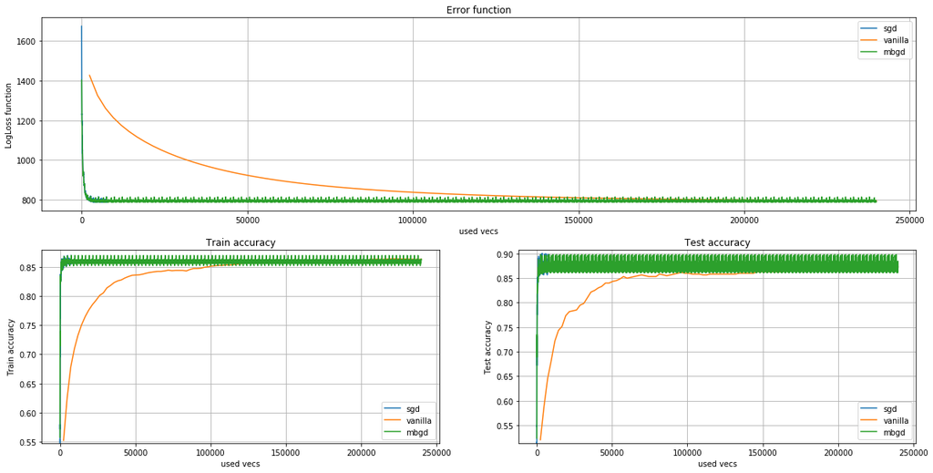

```python
plotting_grid = [plt.subplot(211), plt.subplot(223), plt.subplot(224)]

sgd_ps = plot_stats(sgd_model, 'sgd', plotting_grid)
vgd_ps = plot_stats(vgd_model, 'vanilla', plotting_grid)
mbgd_ps = plot_stats(mbgd_model, 'mbgd', plotting_grid)
```

## Сходимость оптимизации momentum с подобранным $\gamma$

```
Used vectors:  7786
Used vectors:  239900
Used vectors:  239900
```

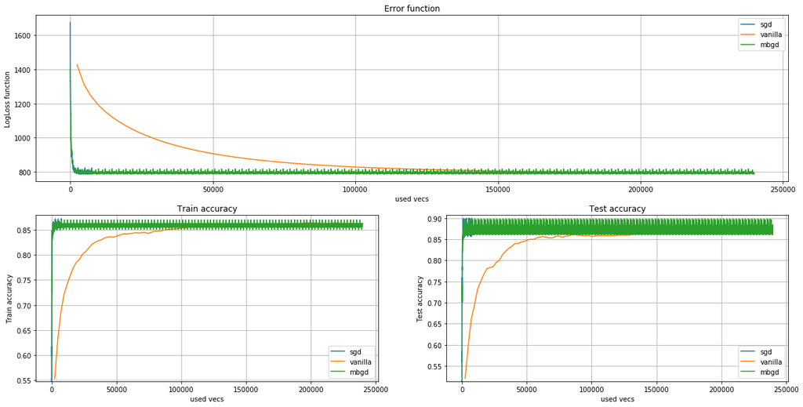

```python
plotting_grid = [plt.subplot(211), plt.subplot(223), plt.subplot(224)]

mm_sgd_ps = plot_stats(momentum_sgd_model, 'sgd', plotting_grid)
mm_vgd_ps = plot_stats(momentum_vgd_model, 'vanilla', plotting_grid)
mm_mbgd_ps = plot_stats(momentum_mbgd_model, 'mbgd', plotting_grid)
```

На представленных графиках видим, что только VGD сходится не так быстро в отличие от других моделей.

```python
def compare_models(models_params, name):
    for params in models_params:
        label = '\u03B3 = ' + str(params['gamma'])
        plt.plot(params['uv'], params['errs'], label=label)

    plt.xlabel('used vectors')
    plt.ylabel('Loss')
    plt.title(name)
    plt.grid()
    plt.legend()
```

## SGD

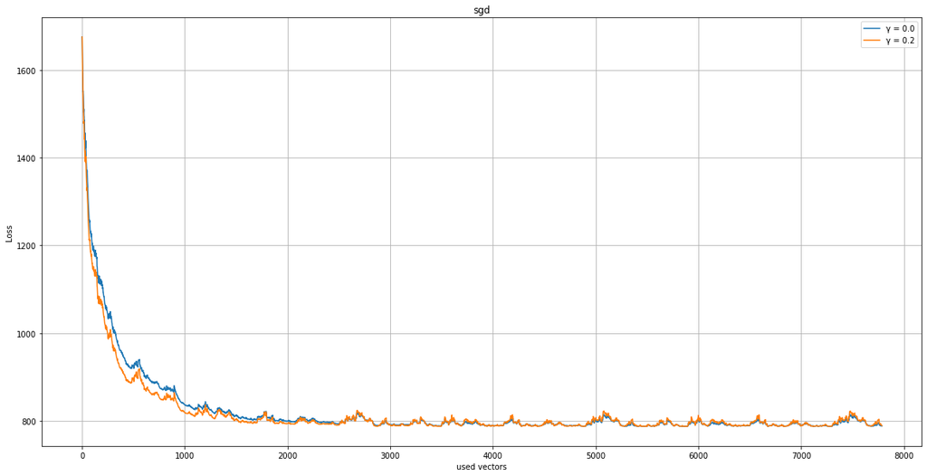

```python
compare_models([sgd_ps, mm_sgd_ps], 'sgd')
```

## VGD

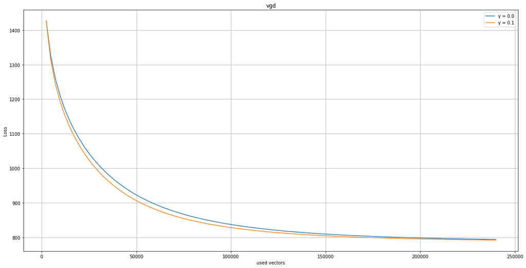

```python
compare_models([vgd_ps, mm_vgd_ps], 'vgd')
```

## MBGD

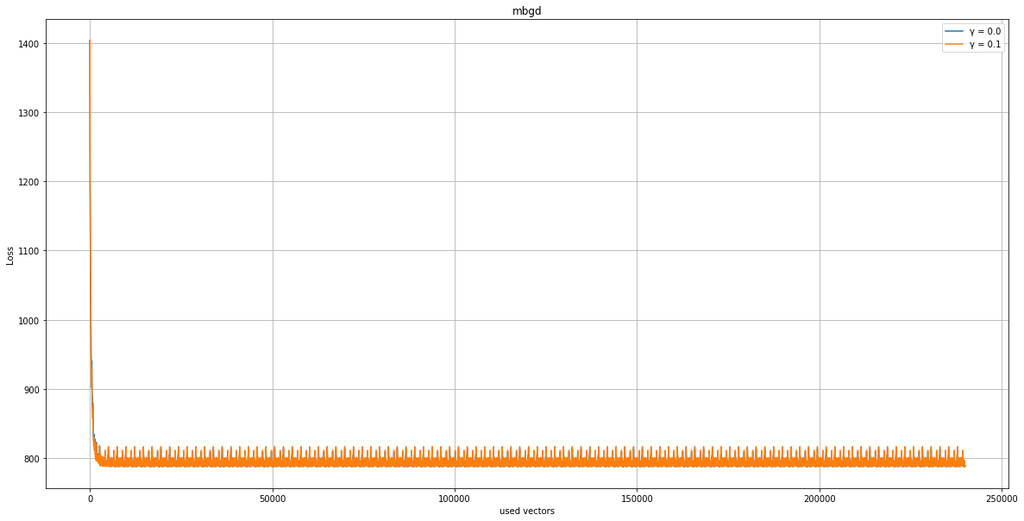

```python
compare_models([mbgd_ps, mm_mbgd_ps], 'mbgd')
```

Как видим, MBGD практически сразу достигает минимума ошибки, SGD чуть медленнее, и VGD сходится медленнее всего.Значение параметра в данных случаях существенно на результат не повлияло.

## График разделения на признаки

```
Line equation: y = 2.615 * x + 2.655
```

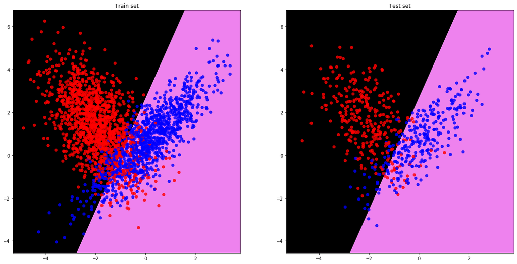

```python
color_map = {0: 'blue', 1: 'red'}

_, (axs0, axs1) = plt.subplots(1, 2)
axs0.scatter(X_train[:, 1], X_train[:, 2], c=np.vectorize(color_map.get)(y_train), alpha=0.8);
axs0.set_title('Train set')
left_x, right_x = axs0.get_xlim()
left_y, right_y = axs0.get_ylim()

axs1.scatter(X_test[:, 1], X_test[:, 2], c=np.vectorize(color_map.get)(y_test), alpha=0.8);
axs1.set_title('Test set')
axs1.set_xlim([left_x, right_x])
axs1.set_ylim([left_y, right_y])

w0, w1, w2 = vgd_model.w_
xx = np.array([left_x, right_x])
yy = (-w1 / w2) * xx + (-w0 / w2)
print(f'Line equation: y = {-w1/w2:.3f} * x + {-w0/w2:.3f}')

axs0.fill_between(xx, yy, right_y, fc='black');
axs0.fill_between(xx, yy, left_y, fc='violet');
axs0.scatter(X_train[:, 1], X_train[:, 2], c=np.vectorize(color_map.get)(y_train), alpha=0.8);
axs0.set_xlim([left_x, right_x]);
axs0.set_ylim([left_y, right_y]);

axs1.fill_between(xx, yy, right_y, fc='black');
axs1.fill_between(xx, yy, left_y, fc='violet');
axs1.scatter(X_test[:, 1], X_test[:, 2], c=np.vectorize(color_map.get)(y_test), alpha=0.8);
axs1.set_xlim([left_x, right_x]);
axs1.set_ylim([left_y, right_y]);
```

Видим разделяющую линейную поверхность.